# Preliminary Analyses

# Average Policy Differences By Race and Class

## Police Fairness Evaluations

### By race

Below I present the distribution for each of the individual police evaluation items. I include both the full sample, and then the white and black only samples respectively. Higher values denote more positive evaluations. Everything is in percentage points. I also report the results from a Chi$^2$ test on these distributions. Unsurprisingly, all of these are significant.

Of these individual items, blacks tend to offer the most negative ratings on the *equal treatment*, *excessive force*, and *accountability* items. For whites, the distribution of repsonses to these items does not appear to meaningfully differ from the rest, at least eyeballing the results.

**Solving Crime**

```
##             black
## p.crim.solve  0  1
##            0  5 19
##            1 11 20
##            2 35 36
##            3 36 17
##            4 13  7
```

```
##
##  Pearson's Chi-squared test
##
## data:  round(prop.table(svytable(~p.crim.solve + black, d.all), 2) *     100)
## X-squared = 19.4, df = 4, p-value = 0.0006556
```

**Protecting people like you from violent crime**

```
##            black
## p.viol.crim  0  1
##           0  4 21
##           1  9 19
##           2 28 34
##           3 40 17
##           4 20  8
```

```
##
##  Pearson's Chi-squared test
##
## data:  round(prop.table(svytable(~p.viol.crim + black, d.all), 2) *     100)
## X-squared = 30.119, df = 4, p-value = 4.63e-06
```

**Treating racial and ethnic groups equally**

```
##            black
## p.race.fair  0  1
##           0 12 43
##           1 13 18
##           2 30 23
##           3 29 11
##           4 16  6
```

```
##
##  Pearson's Chi-squared test
##
## data:  round(prop.table(svytable(~p.race.fair + black, d.all), 2) *     100)
## X-squared = 31.845, df = 4, p-value = 2.058e-06
```

**Not using excessive force on suspects**

```
##              black
## p.exces.force  0  1
##             0  9 35
##             1 13 18
##             2 31 28
##             3 31 12
##             4 16  7
```

```
##
##  Pearson's Chi-squared test
##
## data:  round(prop.table(svytable(~p.exces.force + black, d.all), 2) *     100)
## X-squared = 28.24, df = 4, p-value = 1.115e-05
```

**Holding police officers accountable for misconduct**

```
##          black
## p.account  0  1
##         0 12 44
##         1 12 15
##         2 29 24
##         3 32 11
##         4 15  6
```

```
##
##  Pearson's Chi-squared test
##
## data:  round(prop.table(svytable(~p.account + black, d.all), 2) * 100)
## X-squared = 33.204, df = 4, p-value = 1.085e-06
```

I also considered a summary evaluation index. I summed together the 5 evaluations and set the scale to run from 0-1, where higher values denote more positive evaluations. The mean for the full sample is 0.53, while for whites it is 0.59 and for blacks it is 0.37. Blacks clearly rate the police on average lower than whites, and this difference is significant at p < 0.000. I present the distribution for the scale for the full sample and by race below.

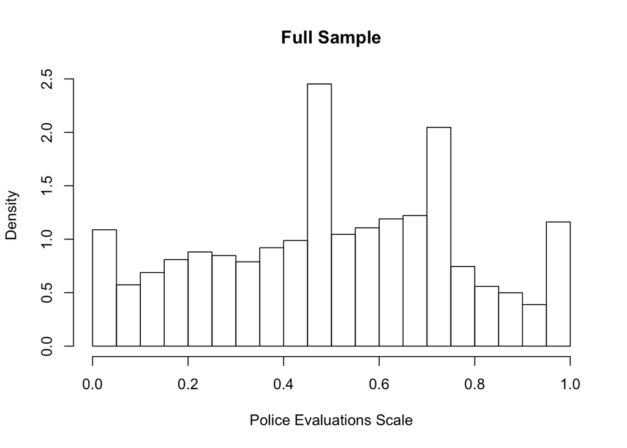

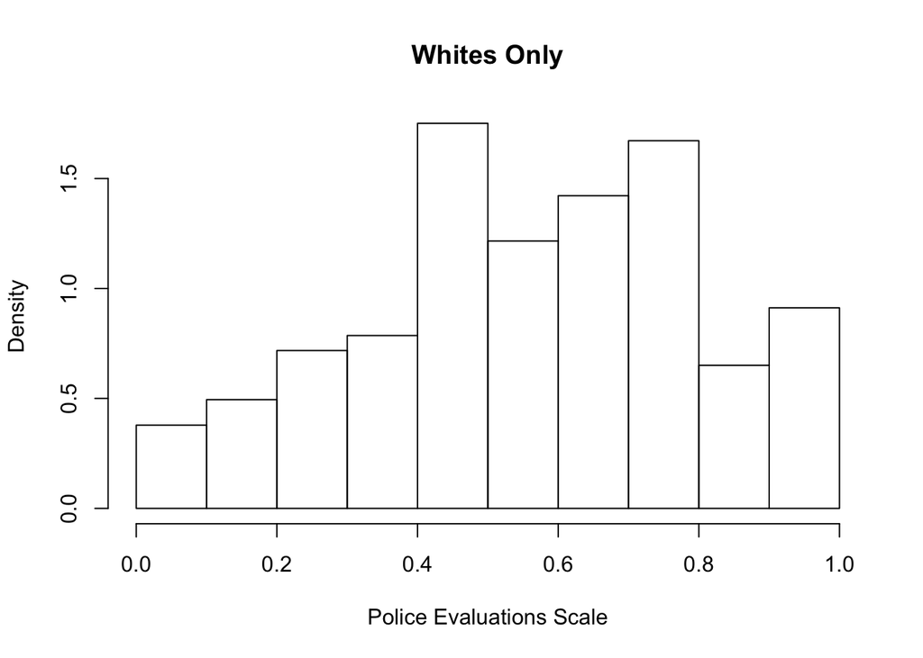

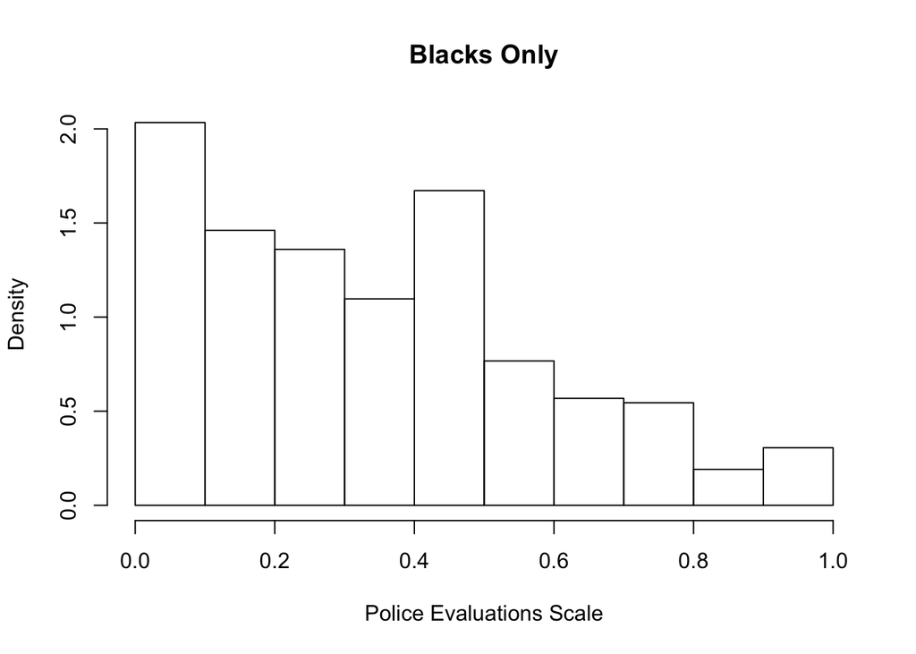

It’s also potentially instructive to contrast whites and blacks in how these police evaluation items scale together. To get a sense for whether these capture summary evaluations across groups, I present alphas for the 5 items scaled together. Cronbach’s alpha for whites is 0.90, while for black it is 0.89. Although a rough pass, the similarity suggests that blacks and whites use the same dimensions to evaluate the police. I could push further on this with some factor analyses if interested.

Race seems closely related to how people evaluate the police in their area. This manifests both in individual and summary item ratings. Importantly, the dimensions on which whites and blacks evaluate the police seem to matter the same.

### By class

I created two separate measure of class based on tercile breakdowns of income and education. Each assigned repondents to an income or education tercile, however one version determined terciles based on the full weighted sample while the second looked within each racial group. Because the correlation between the two measures is 0.92 I use the class measure that’s specific within each race to account for potential incomparabilities across groups. I again included a Chi$^2$ test for each distribution. None of these are significant. Class level does not appear to be related with evaluations of the police. Moreover, response distributions appear to be similar across items, too.

**Solving Crime**

```
##             class
## p.crim.solve  0 0.25 0.5 0.75  1
##            0 13   10   8    6  6
##            1 16   14  14   12 11
##            2 36   36  34   35 35
##            3 24   29  33   36 34
##            4 11   10  11   10 15
```

```
##
##  Pearson's Chi-squared test
##
## data:  round(prop.table(svytable(~p.crim.solve + class, d.all), 2) *     100)
## X-squared = 9.6774, df = 16, p-value = 0.8829
```

**Protecting people like you from violent crime**

```
##            class
## p.viol.crim  0 0.25 0.5 0.75  1
##           0 12   10   8    6  5
##           1 16   13  11    9 11
##           2 32   32  29   29 25
##           3 25   31  35   40 38
##           4 15   15  17   16 21
```

```
##
##  Pearson's Chi-squared test
##
## data:  round(prop.table(svytable(~p.viol.crim + class, d.all), 2) *     100)
## X-squared = 13.171, df = 16, p-value = 0.6602
```

**Treating racial and ethnic groups equally**

```
##            class
## p.race.fair  0 0.25 0.5 0.75  1
##           0 22   22  21   17 19
##           1 16   14  14   14 13
##           2 30   29  27   29 25
##           3 19   23  26   27 28
##           4 13   12  13   13 15
```

```
##
##  Pearson's Chi-squared test
##
## data:  round(prop.table(svytable(~p.race.fair + class, d.all), 2) *     100)
## X-squared = 4.3657, df = 16, p-value = 0.9981
```

**Not using excessive force on suspects**

```
##              class
## p.exces.force  0 0.25 0.5 0.75  1
##             0 19   18  16   14 12
##             1 15   15  14   14 15
##             2 33   32  28   30 26
##             3 20   23  29   28 29
##             4 12   12  13   14 17
```

```
##
##  Pearson's Chi-squared test
##
## data:  round(prop.table(svytable(~p.exces.force + class, d.all), 2) *     100)
## X-squared = 7.124, df = 16, p-value = 0.9708
```

**Holding police officers accountable for misconduct**

```
##          class
## p.account  0 0.25 0.5 0.75  1
##         0 25   22  21   18 17
##         1 13   14  12   12 12
##         2 29   29  27   28 24
##         3 21   23  28   29 31
##         4 12   11  12   13 15
```

```
##
##  Pearson's Chi-squared test
##
## data:  round(prop.table(svytable(~p.account + class, d.all), 2) * 100)
## X-squared = 6.305, df = 16, p-value = 0.9845
```

As for the summary evaluation index, the table below proveis the mean for each class category. Descriptively higher class individuals tend to evaluate the police more positively. A 5 point difference exists between the lowest and highest class individuals, one significant at p < 0.000.

```
##         0 0.25  0.5 0.75    1
## mean 0.51 0.52 0.53 0.54 0.56
```

The plots below present the distribution of summary police evaluations for each class level.

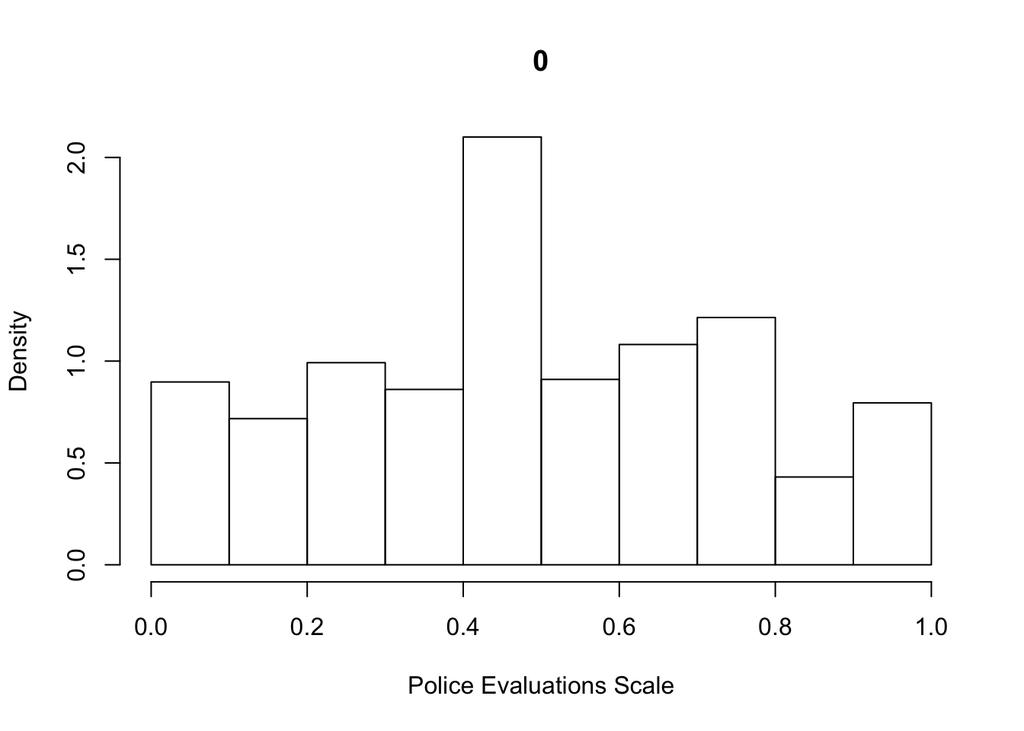

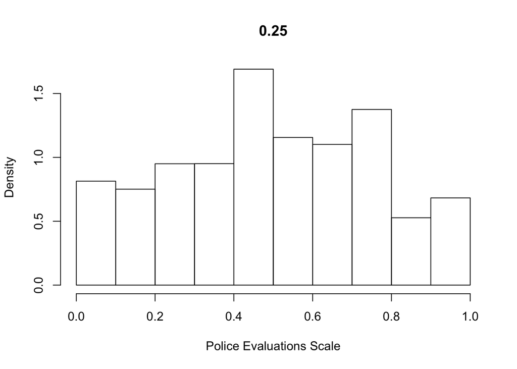

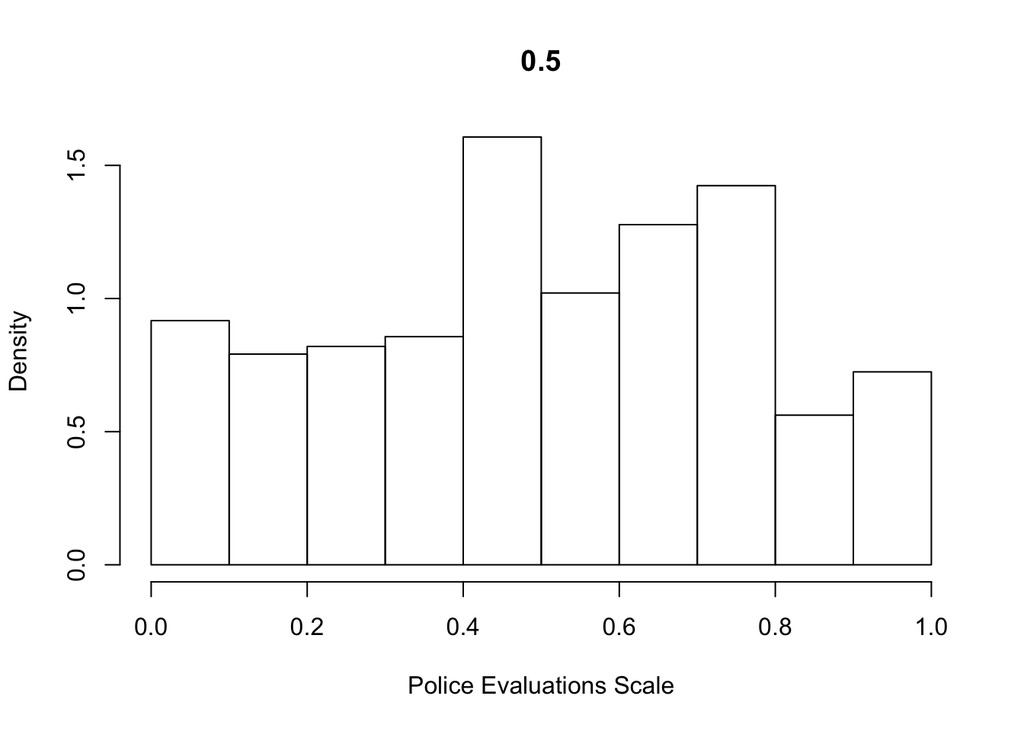

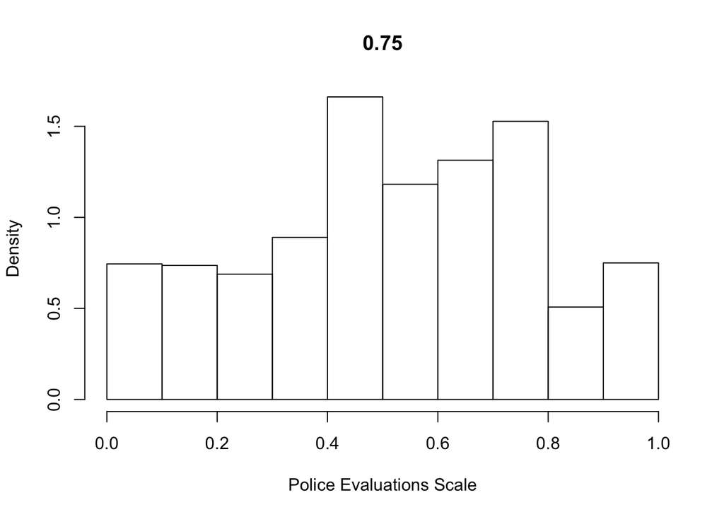

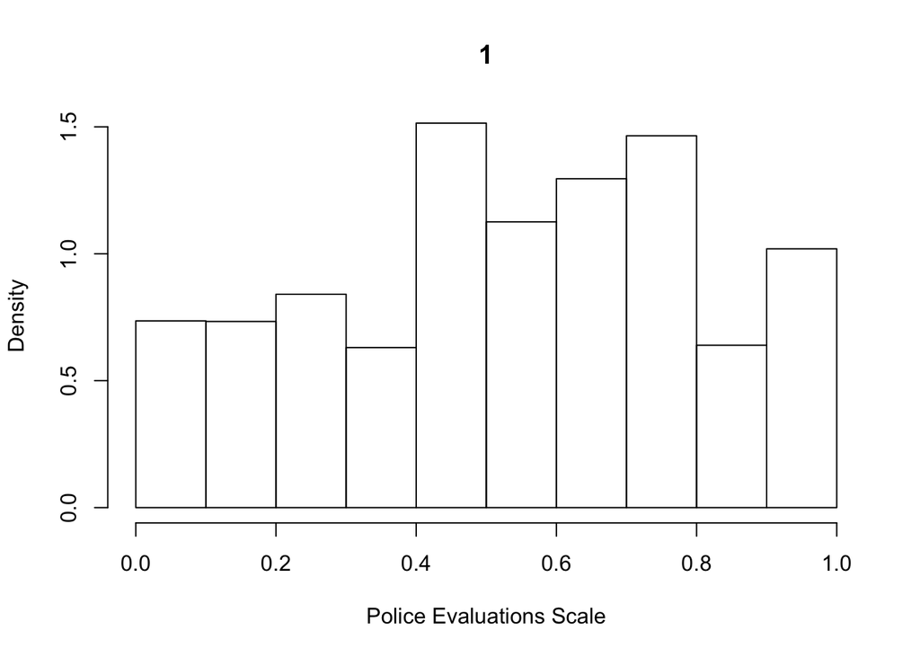

I return to the alpha measure to contrast class category groups’ police evaluations. The table below presents these tallies. No meaningful variation exists by class category, suggesting class does not shape which dimensions people rely on for evaluating the police.

```
##           0  0.25   0.5  0.75     1
## alpha 0.915 0.907 0.914 0.914 0.919
```

### By Race and Class

Finally, for the race and class breakdown I present the item distributions again, but by class within each racial group. I again include Chi$^2$ tests to compare the distributions. None of these tests are significant, suggesting that the intersection of race and class does not affect evaluations of the police.

**Whites: Solving Crime**

```
##             class
## p.crim.solve  0 0.25 0.5 0.75  1
##            0  7    6   4    5  4
##            1 14   12  12   10 10
##            2 37   36  34   35 34
##            3 30   33  38   38 36
##            4 13   12  12   12 16
```

```
##
##  Pearson's Chi-squared test
##
## data:  round(prop.table(svytable(~p.crim.solve + class, d.wht), 2) *     100)
## X-squared = 4.7253, df = 16, p-value = 0.997
```

**Blacks: Solving Crime**

```
##             class
## p.crim.solve  0 0.25 0.5 0.75  1
##            0 20   19  18   12 12
##            1 22   22  21   21 13
##            2 36   35  36   39 44
##            3 14   17  19   24 24
##            4  8    7   6    3  7
```

```
##
##  Pearson's Chi-squared test
##
## data:  round(prop.table(svytable(~p.crim.solve + class, d.blk), 2) *     100)
## X-squared = 14.471, df = 16, p-value = 0.5636
```

**Whites: Protecting people like you from violent crime**

```
##            class
## p.viol.crim  0 0.25 0.5 0.75  1
##           0  6    5   3    4  1
##           1 13   11   9    7  8
##           2 31   32  29   26 23
##           3 32   35  40   44 43
##           4 19   18  19   19 24
```

```
##
##  Pearson's Chi-squared test
##
## data:  round(prop.table(svytable(~p.viol.crim + class, d.wht), 2) *     100)
## X-squared = 12.146, df = 16, p-value = 0.7338
```

**Blacks: Protecting people like you from violent crime**

```
##            class
## p.viol.crim  0 0.25 0.5 0.75  1
##           0 20   21  20   16 21
##           1 22   19  17   18 20
##           2 36   33  34   39 31
##           3 12   21  20   22 19
##           4 10    7   9    4 10
```

```
##
##  Pearson's Chi-squared test
##
## data:  round(prop.table(svytable(~p.viol.crim + class, d.blk), 2) *     100)
## X-squared = 9.3279, df = 16, p-value = 0.8993
```

**Whites: Treating racial and ethnic groups equally**

```
##            class
## p.race.fair  0 0.25 0.5 0.75  1
##           0 13   14  13   11 11
##           1 16   13  12   13 13
##           2 31   31  30   30 26
##           3 24   27  30   30 32
##           4 16   15  15   16 18
```

```
##
##  Pearson's Chi-squared test
##
## data:  round(prop.table(svytable(~p.race.fair + class, d.wht), 2) *     100)
## X-squared = 3.5939, df = 16, p-value = 0.9994
```

**Blacks: Treating racial and ethnic groups equally**

```
##            class
## p.race.fair  0 0.25 0.5 0.75  1
##           0 37   40  44   40 51
##           1 18   17  20   24 15
##           2 28   25  21   23 18
##           3 10   11  12   12 10
##           4  7    6   4    2  6
```

```
##
##  Pearson's Chi-squared test
##
## data:  round(prop.table(svytable(~p.race.fair + class, d.blk), 2) *     100)
## X-squared = 11.3, df = 16, p-value = 0.7906
```

**Whites: Not using excessive force on suspects**

```
##              class
## p.exces.force  0 0.25 0.5 0.75  1
##             0 12   11  10    9  7
##             1 14   14  12   14 14
##             2 34   34  29   30 27
##             3 26   27  33   32 33
##             4 15   15  16   16 19
```

```
##
##  Pearson's Chi-squared test
##
## data:  round(prop.table(svytable(~p.exces.force + class, d.wht), 2) *     100)
## X-squared = 5.2147, df = 16, p-value = 0.9946
```

**Blacks: Not using excessive force on suspects**

```
##              class
## p.exces.force  0 0.25 0.5 0.75  1
##             0 31   35  35   34 32
##             1 17   18  19   19 21
##             2 34   29  26   30 22
##             3 11   13  14   11 15
##             4  6    5   5    5  9
```

```
##
##  Pearson's Chi-squared test
##
## data:  round(prop.table(svytable(~p.exces.force + class, d.blk), 2) *     100)
## X-squared = 6.7311, df = 16, p-value = 0.9781
```

**Whites: Holding police officers accountable for misconduct**

```
##          class
## p.account  0 0.25 0.5 0.75  1
##         0 16   14  12   12 10
##         1 13   14  11   12 12
##         2 30   31  30   28 25
##         3 26   27  33   34 36
##         4 14   13  14   15 17
```

```
##
##  Pearson's Chi-squared test
##
## data:  round(prop.table(svytable(~p.account + class, d.wht), 2) * 100)
## X-squared = 5.9786, df = 16, p-value = 0.9883
```

**Blacks: Holding police officers accountable for misconduct**

```
##          class
## p.account  0 0.25 0.5 0.75  1
##         0 40   41  47   39 50
##         1 15   16  16   17 13
##         2 28   26  20   29 18
##         3 12   12  12   11 10
##         4  6    6   5    4  9
```

```
##
##  Pearson's Chi-squared test
##
## data:  round(prop.table(svytable(~p.account + class, d.blk), 2) * 100)
## X-squared = 9.3722, df = 16, p-value = 0.8973
```

Returning to the summary evaluation index, the table below provides the means for each race/class category. Whereas the prior class-only results indicated that higher class individuals tended to evaluate the police more positively, this seems driven by whites. A 7 point difference exists between the lowest and highest class whites, but this gap is only 2 points for blacks. The former is significant at p < 0.000 while the latter is not (p = 0.703).

```
##                 0 0.25  0.5 0.75    1
## mean - White 0.56 0.57 0.60 0.60 0.63
## mean - Black 0.35 0.38 0.35 0.37 0.37
```

Finally, I present the scale alphas in table below. The first row looks at whites across class, while the second looks at blacks by class. No meaningful variation exists according to class/race interaction, reinforcing the likelihood that people rely on the same dimensions for evaluating the police.

```
##                    0  0.25   0.5  0.75     1
## Alpha - Whites 0.906 0.901 0.897 0.903 0.898
## Alpha - Blacks 0.900 0.884 0.898 0.891 0.907
```

## Court Fairness

### By race

I break down each court fairness item based on the suffix. The first is whether the court will fairly apply the law, while the second two ask whether this is the case regardless of a person’s class or race, resepctively. Again, I presented the response distribution in percentage points, broken down by race. The Chi$^2$ tests are again significant. Regardless of the prompt, blacks are on average less likely to think the courts in their area will be fair.

**‘’fairly apply the law?’’**

```
##                    black
## court.fair           0  1
##   0                  5 16
##   0.333333333333333 14 29
##   0.666666666666667 52 43
##   1                 29 12
```

```
##
##  Pearson's Chi-squared test
##
## data:  round(prop.table(svytable(~court.fair + black, d.all), 2) * 100)
## X-squared = 18.896, df = 3, p-value = 0.0002873
```

**‘’fairly apply the law, regardless of a person’s class?’’**

```
##                    black
## court.fair.class     0  1
##   0                  6 16
##   0.333333333333333 15 27
##   0.666666666666667 49 43
##   1                 30 14
```

```
##
##  Pearson's Chi-squared test
##
## data:  round(prop.table(svytable(~court.fair.class + black, d.all),     2) * 100)
## X-squared = 14.184, df = 3, p-value = 0.002666
```

**‘’fairly apply the law, regardless of a person’s race?’’**

```
##                    black
## court.fair.race      0  1
##   0                  6 21
##   0.333333333333333 14 30
##   0.666666666666667 45 37
##   1                 35 12
```

```
##
##  Pearson's Chi-squared test
##
## data:  round(prop.table(svytable(~court.fair.race + black, d.all), 2) *     100)
## X-squared = 26.187, df = 3, p-value = 8.714e-06
```

We also see interesting treatment effects within racial group. While there are no differences between the baseline condition and the class prime, the race prime decreases blacks’ perceptions that courts will be fair. In contrast, the same prime increases whites’ perceptions of fairness. These differences are small, however. The Cohen’s D effect size for whites is 0.06, whole for blacks it is 0.12. Even so, because of the divergent effects, the black-white gap in fairness evaluations grows by 5 percentage points, from 18 to 23 points.

```
##
## Call:
## lm(formula = court.fair.all ~ court.fair.treat * black, data = cjs.df,
##     weights = wts_whole)
##
## Weighted Residuals:
##      Min       1Q   Median       3Q      Max
## -1.70289 -0.13145 -0.01167  0.21515  1.30115
##
## Coefficients:
##                              Estimate Std. Error t value Pr(>|t|)
## (Intercept)                  0.681538   0.005430 125.504  < 2e-16 ***
## court.fair.treatRace         0.013662   0.007723   1.769 0.076919 .
## court.fair.treatClass       -0.004915   0.007688  -0.639 0.522699
## black                       -0.177522   0.010409 -17.055  < 2e-16 ***
## court.fair.treatRace:black  -0.048872   0.014807  -3.301 0.000967 ***
## court.fair.treatClass:black  0.020124   0.014756   1.364 0.172677
## ---
## Signif. codes:  0 '***' 0.001 '**' 0.01 '*' 0.05 '.' 0.1 ' ' 1
##
## Residual standard error: 0.2839 on 11156 degrees of freedom
##   (4 observations deleted due to missingness)
## Multiple R-squared:  0.08072,    Adjusted R-squared:  0.0803
## F-statistic: 195.9 on 5 and 11156 DF,  p-value: < 2.2e-16
```

### By Class

Turning to class, the analyses below suggest little variation exists by class category in fairness percpetions. Moreover, this holds regardless of the prompt. Even when primed to think about class, low and high class respondents think the courts in their area will fairly apply the law. **``fairly apply the law?’’**

```
##                    class.rac
## court.fair           0 0.25 0.5 0.75  1
##   0                 11    7   9    6  6
##   0.333333333333333 20   20  17   20 15
##   0.666666666666667 47   50  51   48 53
##   1                 22   23  24   27 26
```

```
##
##  Pearson's Chi-squared test
##
## data:  round(prop.table(svytable(~court.fair + class.rac, d.all), 2) *     100)
## X-squared = 4.72, df = 12, p-value = 0.9667
```

**``fairly apply the law, regardless of a person’s class?’’**

```
##                    class.rac
## court.fair.class     0 0.25 0.5 0.75  1
##   0                 10    9   9    9  6
##   0.333333333333333 19   19  17   19 16
##   0.666666666666667 49   46  49   45 48
##   1                 22   25  24   27 31
```

```
##
##  Pearson's Chi-squared test
##
## data:  round(prop.table(svytable(~court.fair.class + class.rac, d.all),     2) * 100)
## X-squared = 3.555, df = 12, p-value = 0.9902
```

**``fairly apply the law, regardless of a person’s race?’’**

```
##                    class.rac
## court.fair.race      0 0.25 0.5 0.75  1
##   0                 12   11   9    8  9
##   0.333333333333333 17   19  20   19 14
##   0.666666666666667 41   44  40   43 48
##   1                 30   25  30   30 29
```

```
##
##  Pearson's Chi-squared test
##
## data:  round(prop.table(svytable(~court.fair.race + class.rac, d.all),     2) * 100)
## X-squared = 3.9198, df = 12, p-value = 0.9848
```

```
##
## Call:
## lm(formula = court.fair.all ~ court.fair.treat * class.rac, data = cjs.df,
##     weights = wts_whole)
##
## Weighted Residuals:
##      Min       1Q   Median       3Q      Max
## -1.62974 -0.21365  0.02581  0.07588  0.91059
##
## Coefficients:
##                                   Estimate Std. Error t value Pr(>|t|)
## (Intercept)                      6.072e-01  8.221e-03  73.856  < 2e-16 ***
## court.fair.treatRace             7.624e-03  1.176e-02   0.648    0.517
## court.fair.treatClass            3.421e-05  1.164e-02   0.003    0.998
## class.rac                        5.662e-02  1.447e-02   3.913 9.19e-05 ***
## court.fair.treatRace:class.rac  -1.513e-02  2.089e-02  -0.724    0.469
## court.fair.treatClass:class.rac  1.509e-03  2.046e-02   0.074    0.941
## ---
## Signif. codes:  0 '***' 0.001 '**' 0.01 '*' 0.05 '.' 0.1 ' ' 1
##
## Residual standard error: 0.2956 on 11156 degrees of freedom
##   (4 observations deleted due to missingness)
## Multiple R-squared:  0.00349,    Adjusted R-squared:  0.003043
## F-statistic: 7.814 on 5 and 11156 DF,  p-value: 2.37e-07
```

### By Race and Class

**Whites: ``fairly apply the law?’’**

```
##                    class.rac
## court.fair           0 0.25 0.5 0.75  1
##   0                  8    5   5    4  4
##   0.333333333333333 19   15  12   14 14
##   0.666666666666667 48   52  55   50 52
##   1                 26   27  28   32 29
```

```
##
##  Pearson's Chi-squared test
##
## data:  round(prop.table(svytable(~court.fair + class.rac, d.wht), 2) *     100)
## X-squared = 5.0985, df = 12, p-value = 0.9546
```

**Blacks: ``fairly apply the law?’’**

```
##                    class.rac
## court.fair           0 0.25 0.5 0.75  1
##   0                 22   11  16   11 12
##   0.333333333333333 26   35  27   35 20
##   0.666666666666667 43   43  44   46 53
##   1                  9   12  13    8 15
```

```
##
##  Pearson's Chi-squared test
##
## data:  round(prop.table(svytable(~court.fair + class.rac, d.blk), 2) *     100)
## X-squared = 16.43, df = 12, p-value = 0.1723
```

**Whites: ``fairly apply the law, regardless of a person’s class?’’**

```
##                    class.rac
## court.fair.class     0 0.25 0.5 0.75  1
##   0                  6    8   7    7  2
##   0.333333333333333 20   18  13   13 10
##   0.666666666666667 50   46  50   48 51
##   1                 24   27  30   32 37
```

```
##
##  Pearson's Chi-squared test
##
## data:  round(prop.table(svytable(~court.fair.class + class.rac, d.wht),     2) * 100)
## X-squared = 11.76, df = 12, p-value = 0.4651
```

**Blacks: ``fairly apply the law, regardless of a person’s class?’’**

```
##                    class.rac
## court.fair.class     0 0.25 0.5 0.75  1
##   0                 25   12  16   15 15
##   0.333333333333333 16   23  29   34 29
##   0.666666666666667 46   45  47   38 41
##   1                 13   20   9   12 15
```

```
##
##  Pearson's Chi-squared test
##
## data:  round(prop.table(svytable(~court.fair.class + class.rac, d.blk),     2) * 100)
## X-squared = 19.288, df = 12, p-value = 0.08181
```

**Whites: ``fairly apply the law, regardless of a person’s race?’’**

```
##                    class.rac
## court.fair.race      0 0.25 0.5 0.75  1
##   0                  8    8   4    6  5
##   0.333333333333333 14   17  16   13 10
##   0.666666666666667 44   44  44   44 52
##   1                 34   30  36   37 33
```

```
##
##  Pearson's Chi-squared test
##
## data:  round(prop.table(svytable(~court.fair.race + class.rac, d.wht),     2) * 100)
## X-squared = 6.2091, df = 12, p-value = 0.9052
```

**Blacks: ``fairly apply the law, regardless of a person’s race?’’**

```
##                    class.rac
## court.fair.race      0 0.25 0.5 0.75  1
##   0                 28   20  19   14 21
##   0.333333333333333 25   24  32   36 32
##   0.666666666666667 33   44  36   45 35
##   1                 14   12  14    5 11
```

```
##
##  Pearson's Chi-squared test
##
## data:  round(prop.table(svytable(~court.fair.race + class.rac, d.blk),     2) * 100)
## X-squared = 16.484, df = 12, p-value = 0.17
```

However, we get more nuance by looking at potential treatment effects. For whites in the class prime, higher class whites are marginally more likely to think the courts in their area are fair. The difference between low and high class whites here is 4 percentage points (p = 0.066). This is on top of a 5 point class difference in the baseline condition (p < 0.000).

```
##
## Call:
## lm(formula = court.fair.all ~ court.fair.treat * class.rac, data = cjs.df,
##     weights = wts_white)
##
## Weighted Residuals:
##      Min       1Q   Median       3Q      Max
## -1.75490 -0.04959 -0.00782  0.21841  0.78941
##
## Coefficients:
##                                  Estimate Std. Error t value Pr(>|t|)
## (Intercept)                      0.650394   0.008860  73.406  < 2e-16 ***
## court.fair.treatRace             0.018690   0.012716   1.470 0.141656
## court.fair.treatClass           -0.020307   0.012447  -1.632 0.102814
## class.rac                        0.054297   0.015789   3.439 0.000587 ***
## court.fair.treatRace:class.rac  -0.006945   0.022665  -0.306 0.759291
## court.fair.treatClass:class.rac  0.040979   0.022318   1.836 0.066379 .
## ---
## Signif. codes:  0 '***' 0.001 '**' 0.01 '*' 0.05 '.' 0.1 ' ' 1
##
## Residual standard error: 0.2764 on 8084 degrees of freedom
##   (3076 observations deleted due to missingness)
## Multiple R-squared:  0.007835,   Adjusted R-squared:  0.007221
## F-statistic: 12.77 on 5 and 8084 DF,  p-value: 2.188e-12
```

As for blacks, a different picture emerges. The results below show a sharp divergence in fairness evaluations by class depending on the question wording. For those receiving the class prime, higher class blacks are 9 points less likely to believe the courts in their area are fair than their lower class counterparts (p < 0.05). Interestingly, a similar effect manifests for higher class blacks receiving the race prime, although the magnitude is smaller and imprecisely estimated ($\beta = -0.07$, p < 0.1).

```
##
## Call:
## lm(formula = court.fair.all ~ court.fair.treat * class.rac, data = cjs.df,
##     weights = wts_black)
##
## Weighted Residuals:
##     Min      1Q  Median      3Q     Max
## -1.2594 -0.1636  0.1036  0.1649  1.2823
##
## Coefficients:
##                                 Estimate Std. Error t value Pr(>|t|)
## (Intercept)                      0.47710    0.01575  30.286   <2e-16 ***
## court.fair.treatRace            -0.00398    0.02242  -0.178   0.8591
## court.fair.treatClass            0.04734    0.02291   2.066   0.0389 *
## class.rac                        0.07406    0.02865   2.585   0.0098 **
## court.fair.treatRace:class.rac  -0.07068    0.04217  -1.676   0.0939 .
## court.fair.treatClass:class.rac -0.09094    0.04075  -2.232   0.0257 *
## ---
## Signif. codes:  0 '***' 0.001 '**' 0.01 '*' 0.05 '.' 0.1 ' ' 1
##
## Residual standard error: 0.3043 on 3066 degrees of freedom
##   (8094 observations deleted due to missingness)
## Multiple R-squared:  0.005924,   Adjusted R-squared:  0.004303
## F-statistic: 3.654 on 5 and 3066 DF,  p-value: 0.002677
```

## Police Respect

We also asked respondents whether give the police more respect would make civilian-police interactions go more smoothly. Higher values denote a belief that being more respectful would lead to more frequent positive interactions. The crosstabs by respondent characteristics suggest that race, not class, shapes these beliefs. Blacks are much less likely than whites to beleif respect leads to consistently positive interactions. 79% of whites believe respect leads to smooth interactions “most of the time” or “always.” In contrast, only 46% of blacks believe this. Consequently, the Chi$^2$ p-value by race is 0.000. Moreover, within racial groups class does not appear to offer any variation. Perpsectives on this item thus appear to follow more from racial background than class.

### By race

```
##               black
## respect.police  0  1
##              0  2 10
##              1 18 44
##              2 49 34
##              3 30 12
```

```
##
##  Pearson's Chi-squared test
##
## data:  round(prop.table(svytable(~respect.police + black, d.all), 2) *     100)
## X-squared = 26.657, df = 3, p-value = 6.946e-06
```

### By Class

```
##               class.rac
## respect.police  0 0.25 0.5 0.75  1
##              0  6    4   5    3  4
##              1 24   25  26   25 27
##              2 45   46  43   46 46
##              3 25   25  27   26 24
```

```
##
##  Pearson's Chi-squared test
##
## data:  round(prop.table(svytable(~respect.police + class.rac, d.all),     2) * 100)
## X-squared = 1.7315, df = 12, p-value = 0.9997
```

### By Race and Class

**Whites**

```
##               class.rac
## respect.police  0 0.25 0.5 0.75  1
##              0  3    2   2    2  2
##              1 20   20  18   16 17
##              2 48   49  47   51 51
##              3 29   29  33   31 30
```

```
##
##  Pearson's Chi-squared test
##
## data:  round(prop.table(svytable(~respect.police + class, d.wht), 2) *     100)
## X-squared = 1.853, df = 12, p-value = 0.9996
```

**Blacks**

```
##               class.rac
## respect.police  0 0.25 0.5 0.75  1
##              0 15    9  11    6  6
##              1 34   39  47   52 53
##              2 37   39  31   32 32
##              3 14   13  11   10  9
```

```
##
##  Pearson's Chi-squared test
##
## data:  round(prop.table(svytable(~respect.police + class, d.blk), 2) *     100)
## X-squared = 13.436, df = 12, p-value = 0.3382
```

## Police Quality “Bad Apples”

Finally, respondents reported whether or not incidents of police corruption were systemic or just “bad apples.” Again, responses vary substantially by race, but not class. 34% of black respondents see these incidents as systemic issues, 23% as bad apples, and 40% a little bit of both. In contrast, 49% of whites focus on bad apples, and only 19% respond that these issues reflect systemic problems. No such variation occurs across class categories. Each class group sees a little over 40% emphasizing bad apples, with between 20 and 26% reponding that it’s a systemic issue. It’s interesting to note that the emphasis on systemic problems rises by class, but the overall distribution doesn’t meaningfully change.

### By race

```
##              black
## pol.badapples  0  1
##             1 49 23
##             2 19 34
##             3 30 40
##             4  1  4
```

```
##
##  Pearson's Chi-squared test
##
## data:  round(prop.table(svytable(~pol.badapples + black, d.all), 2) *     100)
## X-squared = 16.844, df = 3, p-value = 0.0007608
```

### By Class

```
##              class.rac
## pol.badapples  0 0.25 0.5 0.75  1
##             1 42   42  42   43 41
##             2 20   23  23   24 26
##             3 35   33  33   32 31
##             4  3    2   2    1  1
```

```
##
##  Pearson's Chi-squared test
##
## data:  round(prop.table(svytable(~pol.badapples + class.rac, d.all),     2) * 100)
## X-squared = 2.6766, df = 12, p-value = 0.9974
```

### By Race and Class

Turning to within-group differences, nothing signficantly varies. Even so, there’s interesting descriptive variation within blacks. Higher class blacks are less likely to report that police corruption comes from bad apples, and are more likely to emphasize systemic issues, than are lower class blacks. The proportion reporting that both issues matter stays effectively the same.

**Whites**

```
##              class.rac
## pol.badapples  0 0.25 0.5 0.75  1
##             1 45   47  49   51 50
##             2 19   20  19   20 22
##             3 34   31  30   28 27
##             4  2    1   1    1  1
```

```
##
##  Pearson's Chi-squared test
##
## data:  round(prop.table(svytable(~pol.badapples + class, d.wht), 2) *     100)
## X-squared = 2.7666, df = 12, p-value = 0.997
```

**Blacks**

```
##              class.rac
## pol.badapples  0 0.25 0.5 0.75  1
##             1 27   26  22   21 17
##             2 25   29  34   37 41
##             3 42   42  41   41 39
##             4  6    3   3    2  3
```

```
##
##  Pearson's Chi-squared test
##
## data:  round(prop.table(svytable(~pol.badapples + class, d.blk), 2) *     100)
## X-squared = 12.051, df = 12, p-value = 0.4416
```

# Explaining Item Variation

## Police Fairness Evaluations

### Social Experiences

#### Police Abused Friends/Family

**Solving Crime**

```
##
## Call:
## lm(formula = p.crim.solve ~ pol.mistreat * black, data = cjs.df,
##     weights = wts_whole)
##
## Weighted Residuals:
##     Min      1Q  Median      3Q     Max
## -6.1744 -0.5717  0.0530  0.5370  5.9921
##
## Coefficients:
##                    Estimate Std. Error t value Pr(>|t|)
## (Intercept)         2.52071    0.01210 208.406   <2e-16 ***
## pol.mistreat       -0.48348    0.01944 -24.872   <2e-16 ***
## black              -0.59131    0.02641 -22.391   <2e-16 ***
## pol.mistreat:black  0.25704    0.02578   9.969   <2e-16 ***
## ---
## Signif. codes:  0 '***' 0.001 '**' 0.01 '*' 0.05 '.' 0.1 ' ' 1
##
## Residual standard error: 1.016 on 11154 degrees of freedom
##   (8 observations deleted due to missingness)
## Multiple R-squared:  0.1372, Adjusted R-squared:  0.137
## F-statistic: 591.4 on 3 and 11154 DF,  p-value: < 2.2e-16
```

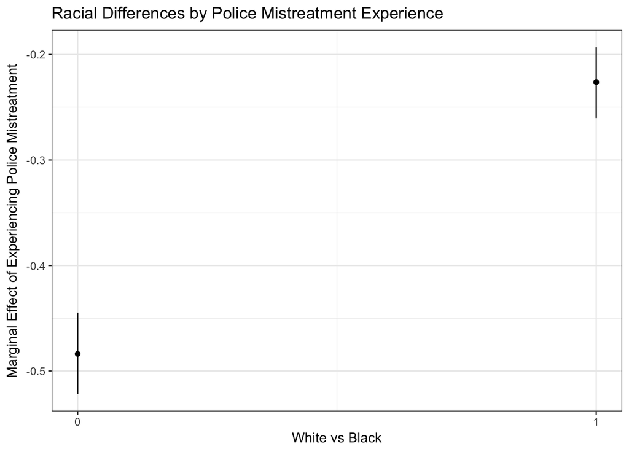

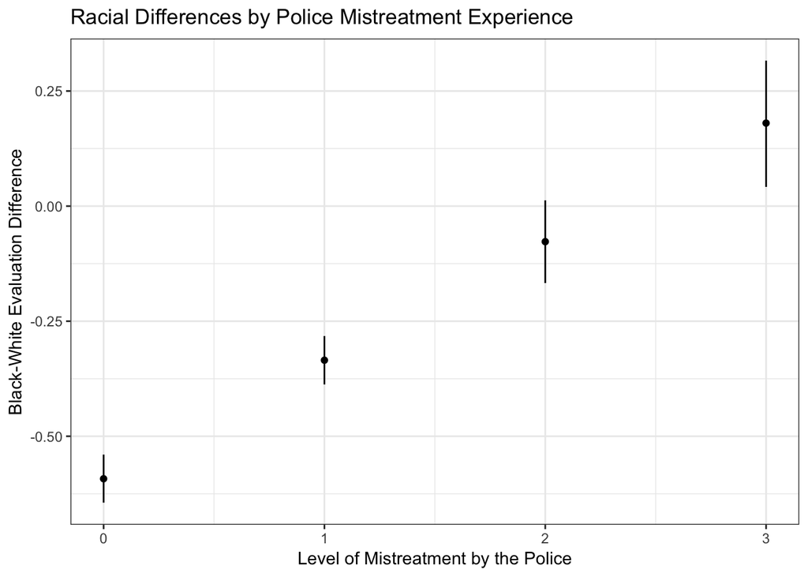

**Protecting people like you from violent crime**

```
##
## Call:
## lm(formula = p.viol.crim ~ pol.mistreat * black, data = cjs.df,
##     weights = wts_whole)
##
## Weighted Residuals:
##     Min      1Q  Median      3Q     Max
## -5.4641 -0.6743  0.1834  0.5440  6.6753
##
## Coefficients:
##                    Estimate Std. Error t value Pr(>|t|)
## (Intercept)         2.74069    0.01224 223.942   <2e-16 ***
## pol.mistreat       -0.50998    0.01967 -25.930   <2e-16 ***
## black              -0.78437    0.02672 -29.351   <2e-16 ***
## pol.mistreat:black  0.23774    0.02609   9.113   <2e-16 ***
## ---
## Signif. codes:  0 '***' 0.001 '**' 0.01 '*' 0.05 '.' 0.1 ' ' 1
##
## Residual standard error: 1.028 on 11152 degrees of freedom
##   (10 observations deleted due to missingness)
## Multiple R-squared:  0.1905, Adjusted R-squared:  0.1903
## F-statistic: 874.7 on 3 and 11152 DF,  p-value: < 2.2e-16
```

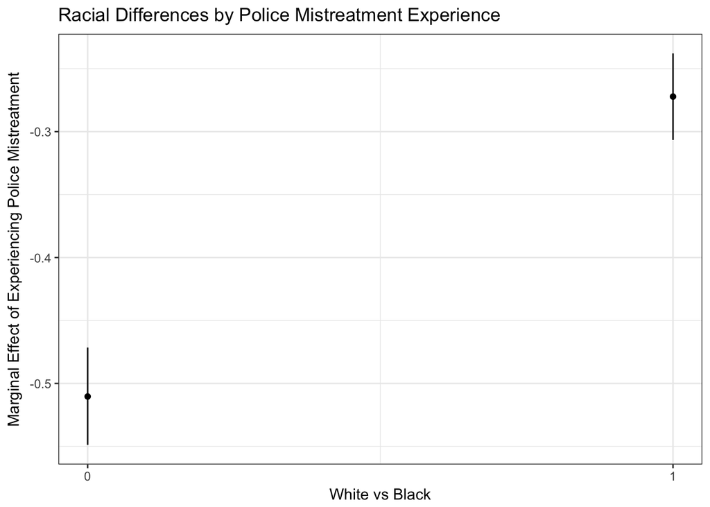

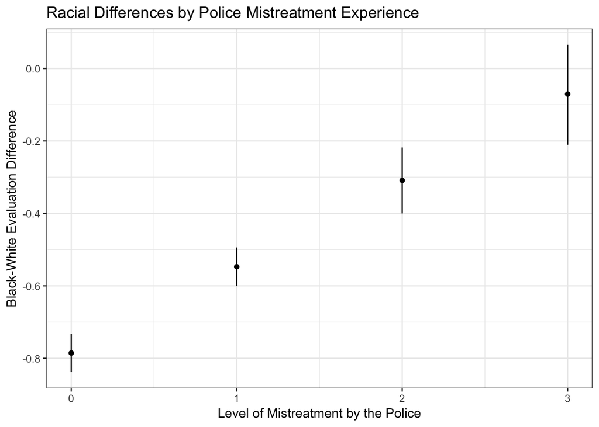

**Treating racial and ethnic groups equally**

```
##
## Call:
## lm(formula = p.race.fair ~ pol.mistreat * black, data = cjs.df,
##     weights = wts_whole)
##
## Weighted Residuals:
##     Min      1Q  Median      3Q     Max
## -5.7739 -0.8841 -0.2526  0.6948  6.9844
##
## Coefficients:
##                    Estimate Std. Error t value Pr(>|t|)
## (Intercept)         2.35718    0.01416 166.417   <2e-16 ***
## pol.mistreat       -0.52268    0.02276 -22.970   <2e-16 ***
## black              -0.94631    0.03093 -30.598   <2e-16 ***
## pol.mistreat:black  0.26043    0.03019   8.627   <2e-16 ***
## ---
## Signif. codes:  0 '***' 0.001 '**' 0.01 '*' 0.05 '.' 0.1 ' ' 1
##
## Residual standard error: 1.19 on 11152 degrees of freedom
##   (10 observations deleted due to missingness)
## Multiple R-squared:  0.1789, Adjusted R-squared:  0.1787
## F-statistic: 809.9 on 3 and 11152 DF,  p-value: < 2.2e-16
```

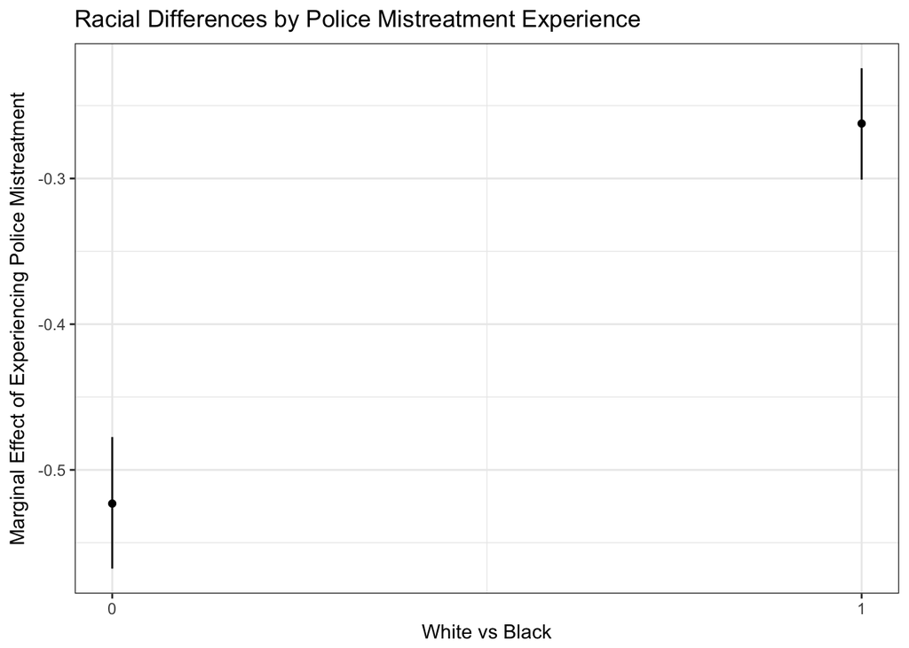

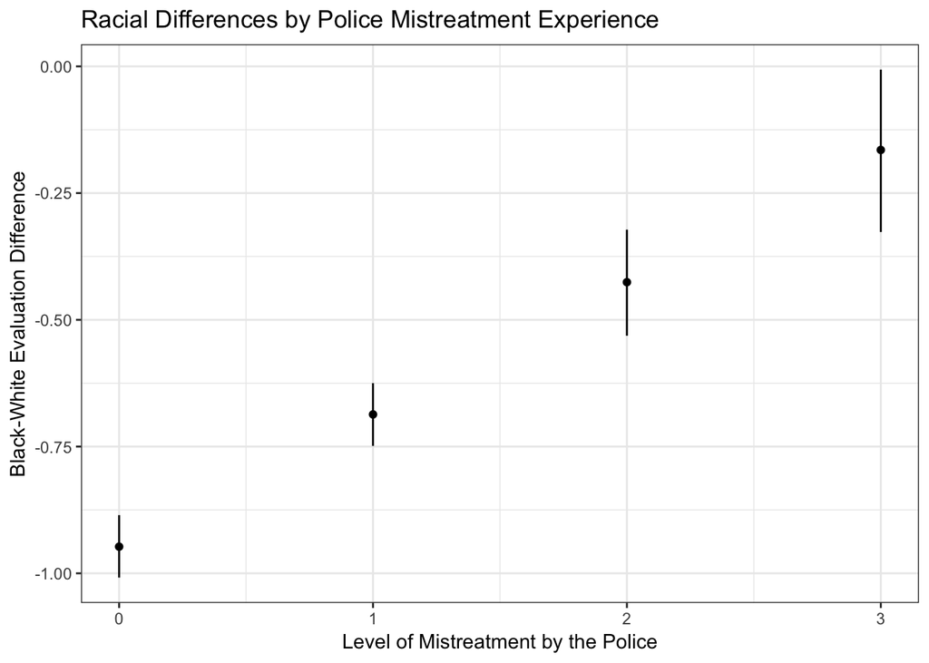

**Not using excessive force on suspects**

```
##
## Call:
## lm(formula = p.exces.force ~ pol.mistreat * black, data = cjs.df,
##     weights = wts_whole)
##
## Weighted Residuals:
##     Min      1Q  Median      3Q     Max
## -5.9396 -0.7881 -0.2500  0.6481  7.2061
##
## Coefficients:
##                    Estimate Std. Error t value Pr(>|t|)
## (Intercept)         2.42485    0.01378  175.99   <2e-16 ***
## pol.mistreat       -0.51897    0.02214  -23.44   <2e-16 ***
## black              -0.85057    0.03009  -28.27   <2e-16 ***
## pol.mistreat:black  0.29826    0.02937   10.15   <2e-16 ***
## ---
## Signif. codes:  0 '***' 0.001 '**' 0.01 '*' 0.05 '.' 0.1 ' ' 1
##
## Residual standard error: 1.158 on 11150 degrees of freedom
##   (12 observations deleted due to missingness)
## Multiple R-squared:  0.1573, Adjusted R-squared:  0.1571
## F-statistic: 693.7 on 3 and 11150 DF,  p-value: < 2.2e-16
```

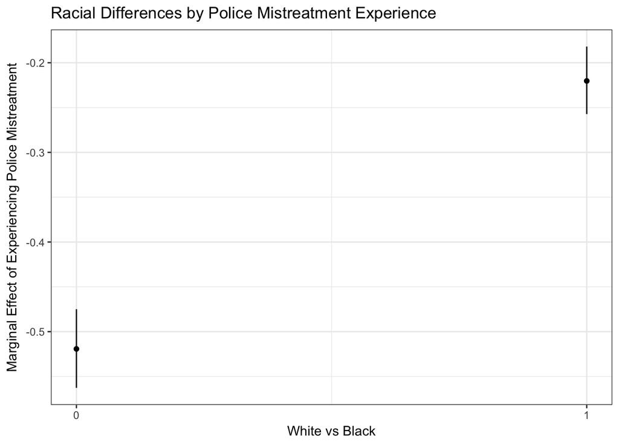

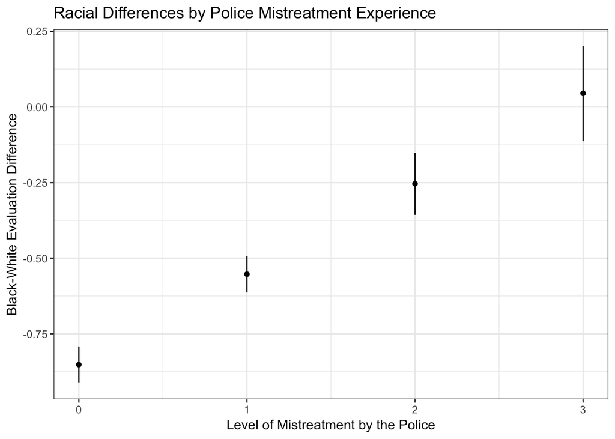

**Holding police officers accountable for misconduct**

```
##
## Call:
## lm(formula = p.account ~ pol.mistreat * black, data = cjs.df,
##     weights = wts_whole)
##
## Weighted Residuals:
##     Min      1Q  Median      3Q     Max
## -5.8363 -0.8614 -0.2706  0.6718  6.9254
##
## Coefficients:
##                    Estimate Std. Error t value Pr(>|t|)
## (Intercept)         2.38266    0.01407  169.36   <2e-16 ***
## pol.mistreat       -0.58220    0.02261  -25.75   <2e-16 ***
## black              -0.95956    0.03072  -31.23   <2e-16 ***
## pol.mistreat:black  0.33182    0.02999   11.06   <2e-16 ***
## ---
## Signif. codes:  0 '***' 0.001 '**' 0.01 '*' 0.05 '.' 0.1 ' ' 1
##
## Residual standard error: 1.182 on 11152 degrees of freedom
##   (10 observations deleted due to missingness)
## Multiple R-squared:  0.1856, Adjusted R-squared:  0.1853
## F-statistic: 846.9 on 3 and 11152 DF,  p-value: < 2.2e-16
```

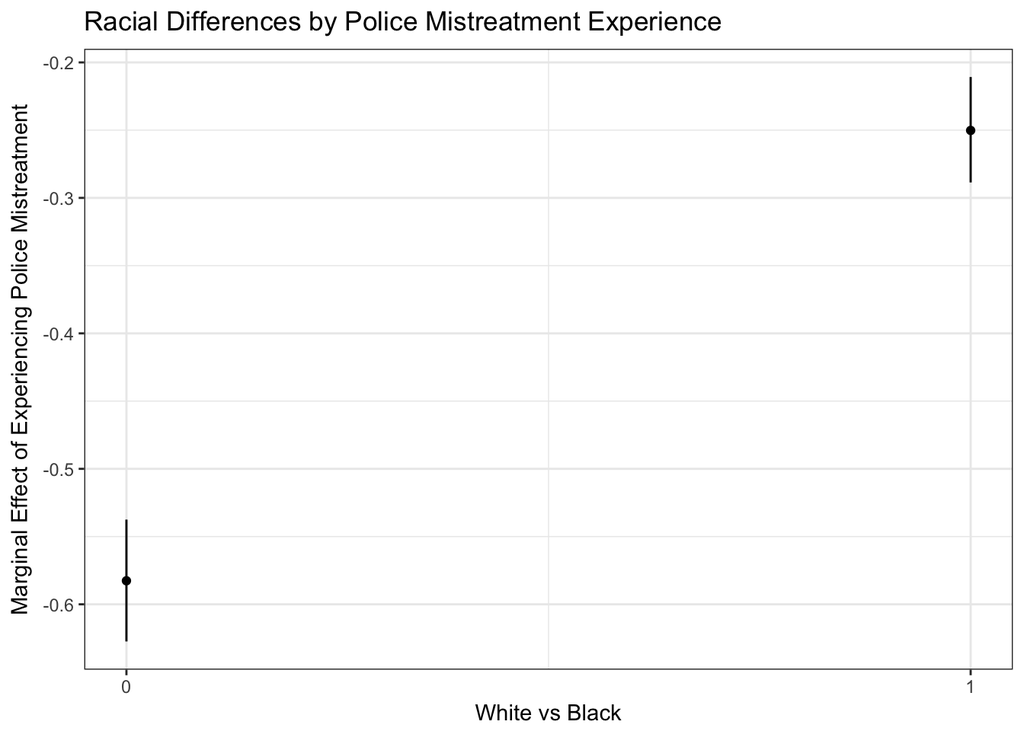

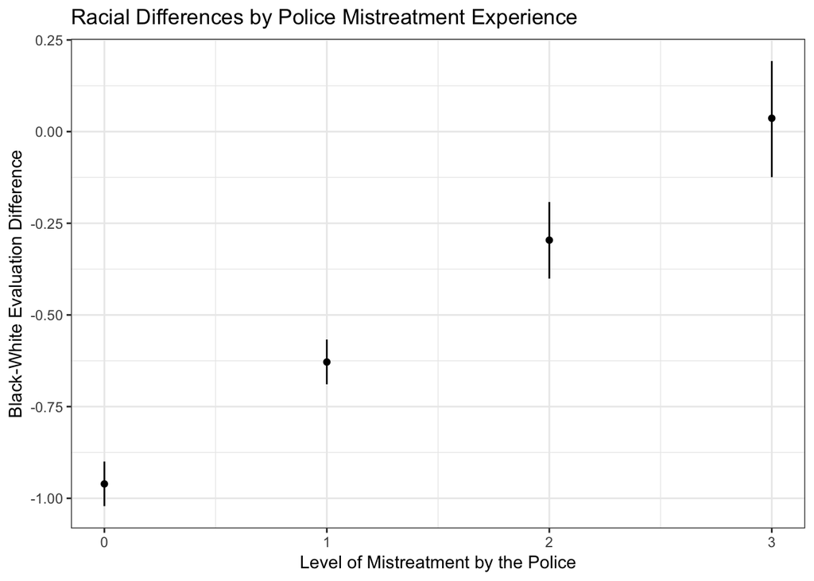

**Summary Evaluation Index**

```
##
## Call:
## lm(formula = police.rate.sc ~ pol.mistreat * black, data = cjs.df,
##     weights = wts_whole)
##
## Weighted Residuals:
##      Min       1Q   Median       3Q      Max
## -1.23513 -0.15647 -0.01505  0.12969  1.58443
##
## Coefficients:
##                     Estimate Std. Error t value Pr(>|t|)
## (Intercept)         0.621289   0.002772  224.13   <2e-16 ***
## pol.mistreat       -0.130705   0.004454  -29.34   <2e-16 ***
## black              -0.206551   0.006052  -34.13   <2e-16 ***
## pol.mistreat:black  0.069126   0.005908   11.70   <2e-16 ***
## ---
## Signif. codes:  0 '***' 0.001 '**' 0.01 '*' 0.05 '.' 0.1 ' ' 1
##
## Residual standard error: 0.2329 on 11146 degrees of freedom
##   (16 observations deleted due to missingness)
## Multiple R-squared:  0.2263, Adjusted R-squared:  0.2261
## F-statistic:  1087 on 3 and 11146 DF,  p-value: < 2.2e-16
```

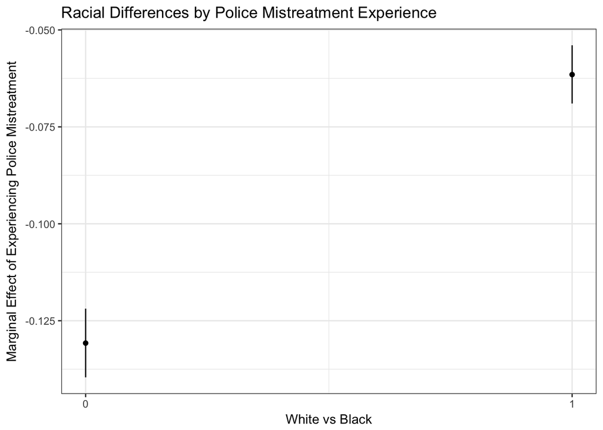

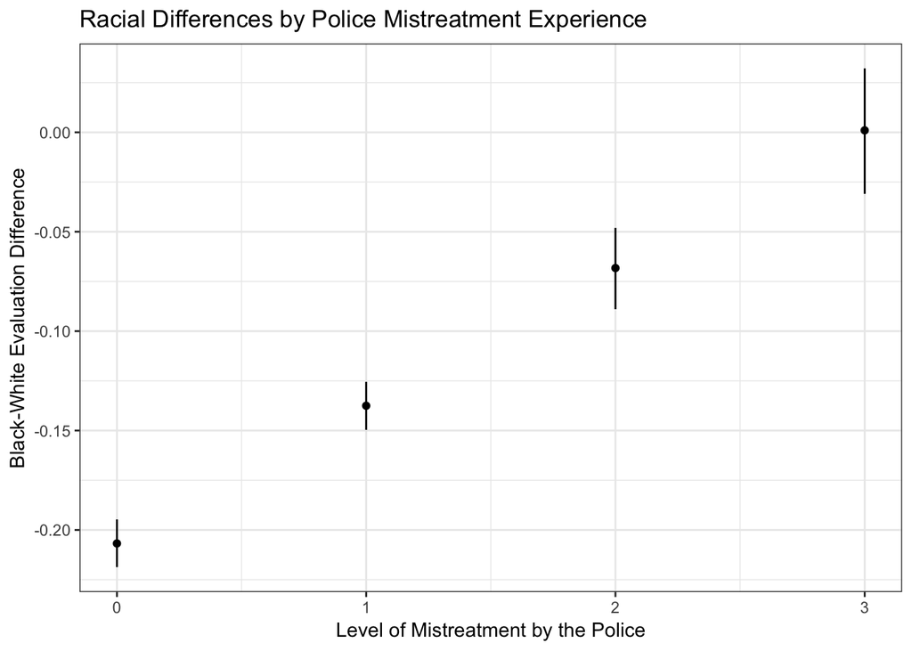

#### Peers convicted of a Felony

I now turn to conditioning on whether a respondent has friends or family with felony convictions. Across all items, respondents with peers who have experienced a felony are less positive in their evaluations of the police. As with the police mistreatment item, in many cases the black-white evaluation gap closes as the number of peers with convictions increases. The gaps remain, but they grow smaller by varying degrees. Finally, relative to being mistreated by the police, the effect of social connections with felony convictions is smaller.

**Solving Crime**

```
##
## Call:
## lm(formula = p.crim.solve ~ peer.felony * black, data = cjs.df,
##     weights = wts_whole)
##
## Weighted Residuals:
##     Min      1Q  Median      3Q     Max
## -6.1040 -0.5601  0.0758  0.5627  5.6223
##
## Coefficients:
##                   Estimate Std. Error t value Pr(>|t|)
## (Intercept)        2.49197    0.01284 194.060   <2e-16 ***
## peer.felony       -0.23327    0.01655 -14.095   <2e-16 ***
## black             -0.59912    0.02723 -22.004   <2e-16 ***
## peer.felony:black  0.04514    0.02432   1.856   0.0634 .
## ---
## Signif. codes:  0 '***' 0.001 '**' 0.01 '*' 0.05 '.' 0.1 ' ' 1
##
## Residual standard error: 1.038 on 11155 degrees of freedom
##   (7 observations deleted due to missingness)
## Multiple R-squared:  0.1005, Adjusted R-squared:  0.1003
## F-statistic: 415.6 on 3 and 11155 DF,  p-value: < 2.2e-16
```

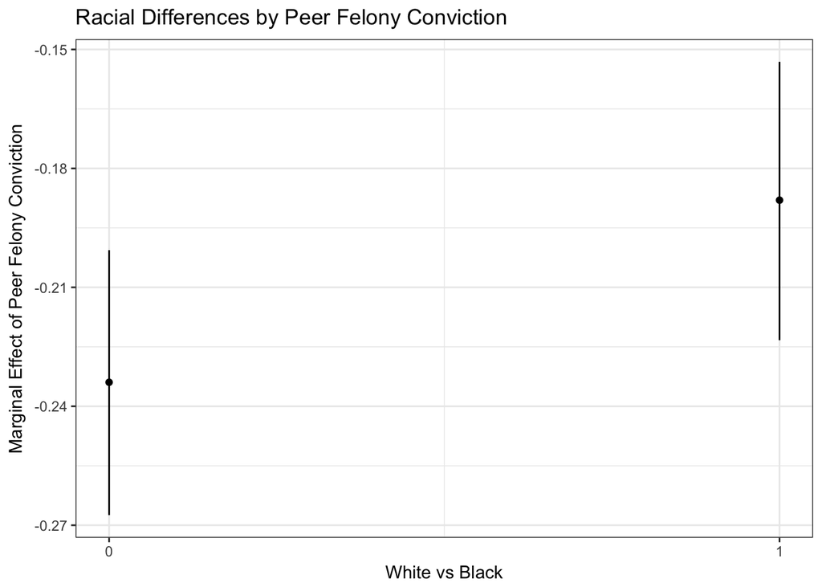

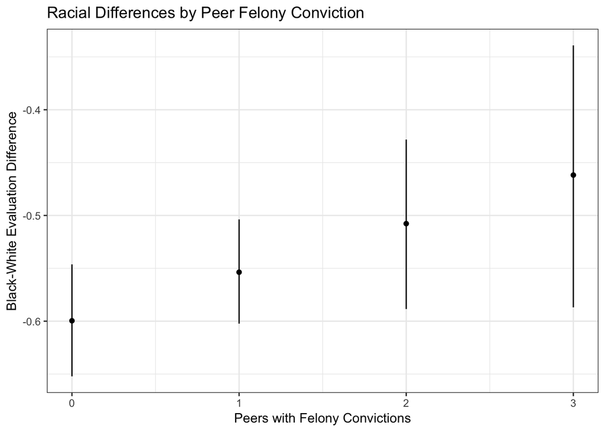

**Protecting people like you from violent crime**

```
##
## Call:
## lm(formula = p.viol.crim ~ peer.felony * black, data = cjs.df,
##     weights = wts_whole)
##
## Weighted Residuals:
##     Min      1Q  Median      3Q     Max
## -6.0102 -0.6415  0.2009  0.4893  6.1834
##
## Coefficients:
##                   Estimate Std. Error t value Pr(>|t|)
## (Intercept)        2.71594    0.01305 208.139  < 2e-16 ***
## peer.felony       -0.26227    0.01682 -15.596  < 2e-16 ***
## black             -0.84897    0.02767 -30.684  < 2e-16 ***
## peer.felony:black  0.09007    0.02471   3.644 0.000269 ***
## ---
## Signif. codes:  0 '***' 0.001 '**' 0.01 '*' 0.05 '.' 0.1 ' ' 1
##
## Residual standard error: 1.054 on 11153 degrees of freedom
##   (9 observations deleted due to missingness)
## Multiple R-squared:  0.1488, Adjusted R-squared:  0.1486
## F-statistic: 650.1 on 3 and 11153 DF,  p-value: < 2.2e-16
```

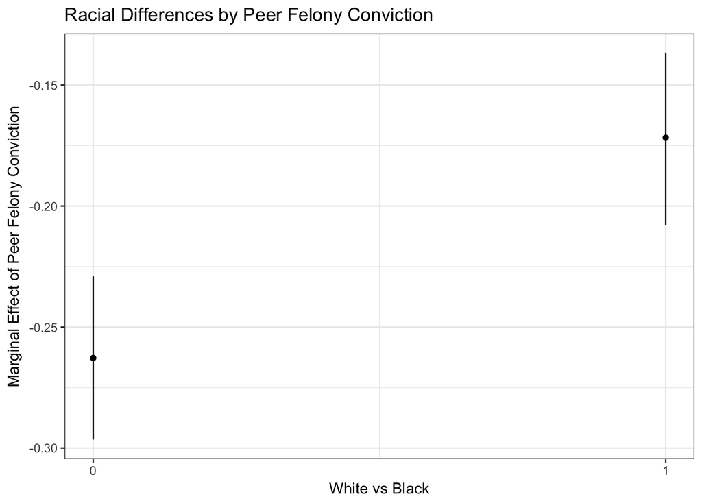

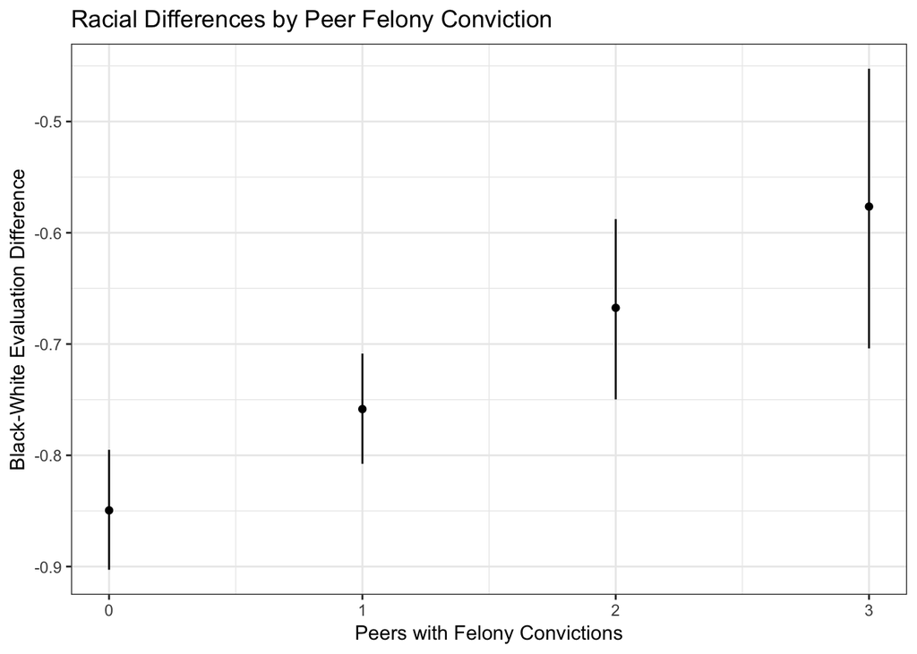

**Treating racial and ethnic groups equally**

```
##
## Call:
## lm(formula = p.race.fair ~ peer.felony * black, data = cjs.df,
##     weights = wts_whole)
##
## Weighted Residuals:
##     Min      1Q  Median      3Q     Max
## -5.6562 -0.9234 -0.2186  0.7366  6.9498
##
## Coefficients:
##                   Estimate Std. Error t value Pr(>|t|)
## (Intercept)        2.30912    0.01508 153.119   <2e-16 ***
## peer.felony       -0.20361    0.01942 -10.484   <2e-16 ***
## black             -1.00319    0.03197 -31.377   <2e-16 ***
## peer.felony:black  0.06045    0.02855   2.117   0.0343 *
## ---
## Signif. codes:  0 '***' 0.001 '**' 0.01 '*' 0.05 '.' 0.1 ' ' 1
##
## Residual standard error: 1.218 on 11153 degrees of freedom
##   (9 observations deleted due to missingness)
## Multiple R-squared:  0.1392, Adjusted R-squared:  0.139
## F-statistic: 601.2 on 3 and 11153 DF,  p-value: < 2.2e-16
```

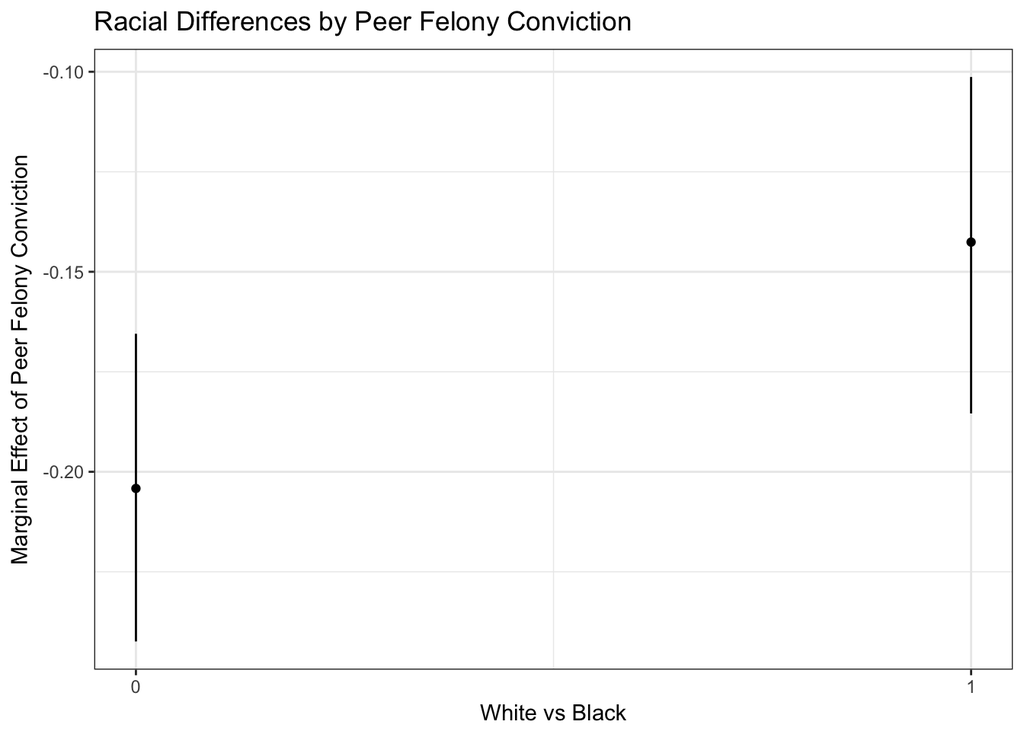

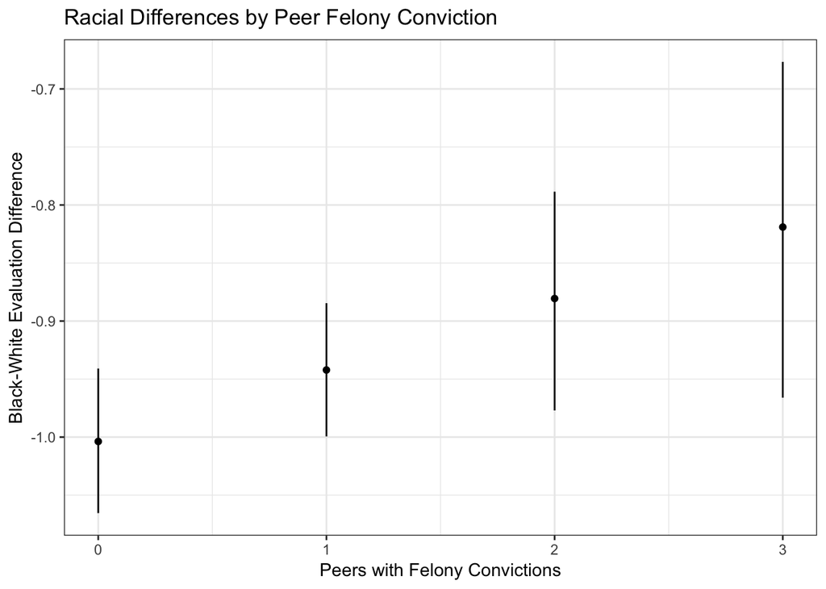

**Not using excessive force on suspects**

```
##
## Call:
## lm(formula = p.exces.force ~ peer.felony * black, data = cjs.df,
##     weights = wts_whole)
##
## Weighted Residuals:
##     Min      1Q  Median      3Q     Max
## -5.8550 -0.8960 -0.1628  0.6672  6.7746
##
## Coefficients:
##                   Estimate Std. Error t value Pr(>|t|)
## (Intercept)        2.39029    0.01462 163.455  < 2e-16 ***
## peer.felony       -0.23960    0.01885 -12.714  < 2e-16 ***
## black             -0.89382    0.03101 -28.826  < 2e-16 ***
## peer.felony:black  0.10645    0.02770   3.843 0.000122 ***
## ---
## Signif. codes:  0 '***' 0.001 '**' 0.01 '*' 0.05 '.' 0.1 ' ' 1
##
## Residual standard error: 1.182 on 11151 degrees of freedom
##   (11 observations deleted due to missingness)
## Multiple R-squared:  0.122,  Adjusted R-squared:  0.1217
## F-statistic: 516.4 on 3 and 11151 DF,  p-value: < 2.2e-16
```

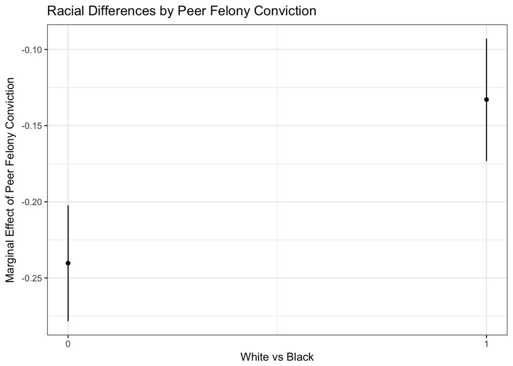

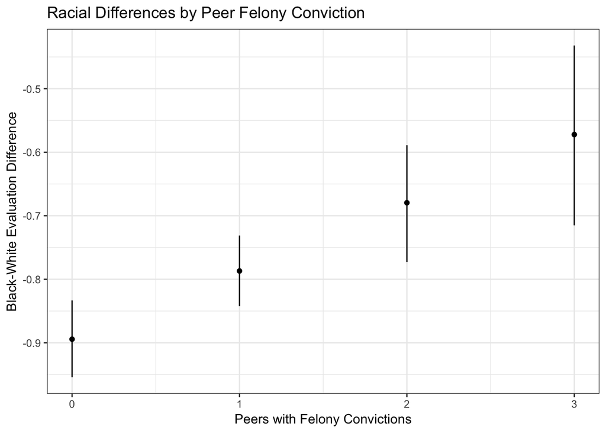

**Holding police officers accountable for misconduct**

```
##
## Call:
## lm(formula = p.account ~ peer.felony * black, data = cjs.df,
##     weights = wts_whole)
##
## Weighted Residuals:
##     Min      1Q  Median      3Q     Max
## -5.7607 -0.9469 -0.2398  0.7082  6.9000
##
## Coefficients:
##                   Estimate Std. Error t value Pr(>|t|)
## (Intercept)        2.35178    0.01497 157.104  < 2e-16 ***
## peer.felony       -0.29171    0.01929 -15.120  < 2e-16 ***
## black             -1.01260    0.03175 -31.898  < 2e-16 ***
## peer.felony:black  0.13562    0.02835   4.783 1.75e-06 ***
## ---
## Signif. codes:  0 '***' 0.001 '**' 0.01 '*' 0.05 '.' 0.1 ' ' 1
##
## Residual standard error: 1.21 on 11153 degrees of freedom
##   (9 observations deleted due to missingness)
## Multiple R-squared:  0.1471, Adjusted R-squared:  0.1469
## F-statistic: 641.3 on 3 and 11153 DF,  p-value: < 2.2e-16
```

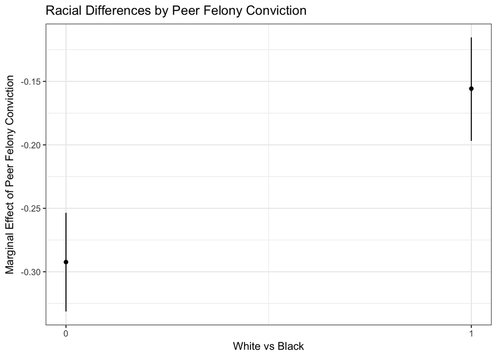

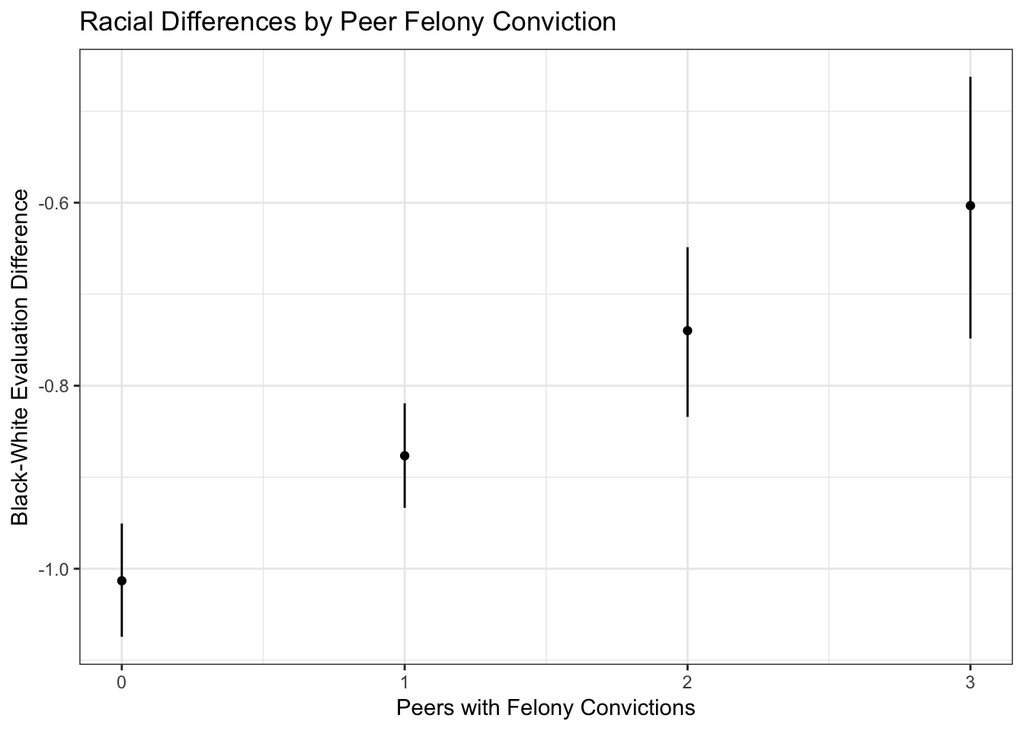

**Summary Evaluation Index**

```
##
## Call:
## lm(formula = police.rate.sc ~ peer.felony * black, data = cjs.df,
##     weights = wts_whole)
##
## Weighted Residuals:
##      Min       1Q   Median       3Q      Max
## -1.22872 -0.16369 -0.01091  0.13872  1.57875
##
## Coefficients:
##                    Estimate Std. Error t value Pr(>|t|)
## (Intercept)        0.612879   0.002977 205.881  < 2e-16 ***
## peer.felony       -0.061256   0.003837 -15.963  < 2e-16 ***
## black             -0.217679   0.006312 -34.488  < 2e-16 ***
## peer.felony:black  0.021532   0.005639   3.818 0.000135 ***
## ---
## Signif. codes:  0 '***' 0.001 '**' 0.01 '*' 0.05 '.' 0.1 ' ' 1
##
## Residual standard error: 0.2405 on 11147 degrees of freedom
##   (15 observations deleted due to missingness)
## Multiple R-squared:  0.1747, Adjusted R-squared:  0.1745
## F-statistic: 786.8 on 3 and 11147 DF,  p-value: < 2.2e-16
```

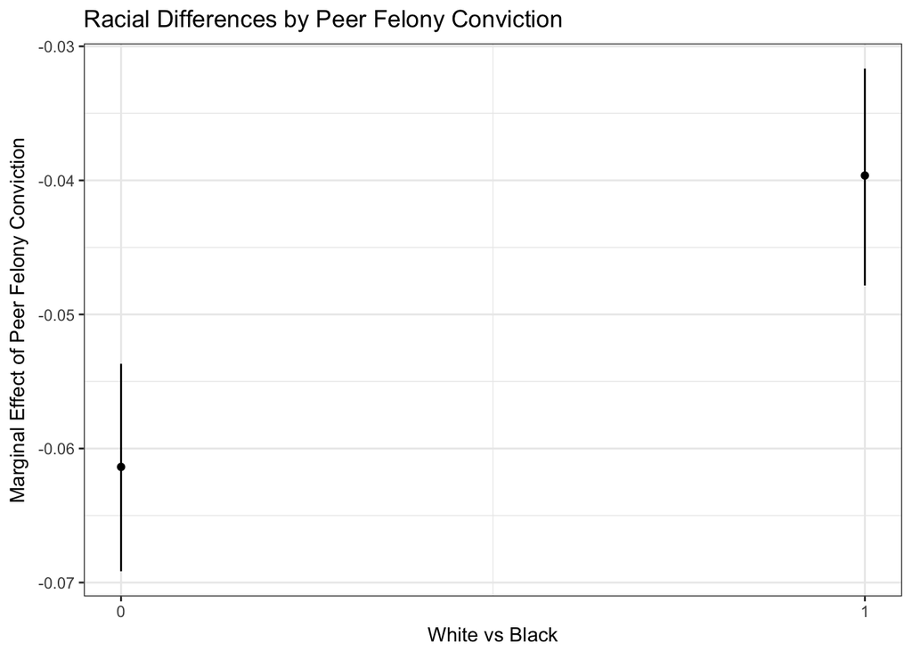

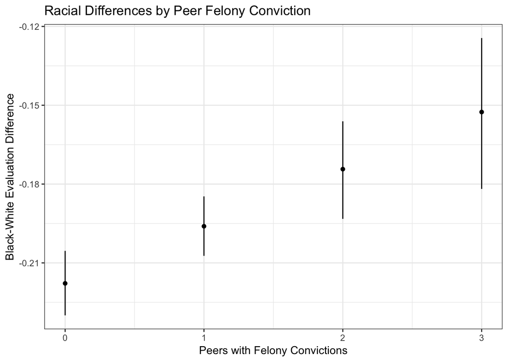

### Employment

### Racial Group Views

### Class Fragility

## Court Fairness

### Social Experiences

### Employment

### Racial Group Views

### Class Fragility

## Police Respect

### Social Experiences

### Employment

### Racial Group Views

### Class Fragility

## Police Quality “Bad Apples”

### Social Experiences

### Employment

### Racial Group Views

### Class Fragility